# Gapminder Data Analysis

Isaac Yeoh

2023-02-19

## 1. Load and check the data (5 points)

Your first task is to do a very simple data check:

2. (2pt) Load data. How many rows/columns do we have?

```r
library(tidyverse)
gapminder <- read_delim("data/gapminder.csv")
```

- We have 13055 number of rows and 25 number of columns.
3. (2pt) Print a small sample of data. Does it look OK?

```r
head(gapminder, 3)
```

```
## # A tibble: 3 × 25
##   iso3  name  iso2  region sub-r…¹ inter…²  time total…³ ferti…⁴ lifeE…⁵ child…⁶
##   <chr> <chr> <chr> <chr>  <chr>   <chr>   <dbl>   <dbl>   <dbl>   <dbl>   <dbl>
## 1 ABW   Aruba AW    Ameri… Latin … Caribb…  1960   54211    4.82    65.7      NA
## 2 ABW   Aruba AW    Ameri… Latin … Caribb…  1961   55438    4.66    66.1      NA
## 3 ABW   Aruba AW    Ameri… Latin … Caribb…  1962   56225    4.47    66.4      NA
## # … with 14 more variables: youthFemaleLiteracy <dbl>, youthMaleLiteracy <dbl>,
## #   adultLiteracy <dbl>, GDP_PC <dbl>, accessElectricity <dbl>,
## #   agriculturalLand <dbl>, agricultureTractors <dbl>, cerealProduction <dbl>,
## #   fertilizerHa <dbl>, co2 <dbl>, greenhouseGases <dbl>, co2_PC <dbl>,
## #   pm2.5_35 <dbl>, battleDeaths <dbl>, and abbreviated variable names
## #   ¹`sub-region`, ²`intermediate-region`, ³totalPopulation, ⁴fertilityRate,
## #   ⁵lifeExpectancy, ⁶childMortality
```

- Yes it looks ok.

## 2. Descriptive statistics (15pt)

1. (3pt) How many countries are there in the dataset? Analyze all three: iso3, iso2 and name.
- There are 253 number of iso3 countries, 249 number of iso2 countries, and 250 number of country names
1. (5pt) Find how many names are there for each iso-2 code. Are there any iso-2 codes that correspond to more than one name? What are these countries?

```r
gapminder %>%
  group_by(iso2) %>%
  summarize(num = n_distinct(name)) %>%
  arrange(desc(num)) %>%
  head(3)
```

```
## # A tibble: 3 × 2
##   iso2    num
##   <chr> <int>
## 1 <NA>      2
## 2 AD        1
## 3 AE        1
```

```r
gapminder %>%
  group_by(iso2) %>%
  filter(is.na(iso2)) %>%
  reframe(country = unique(name))
```

```
## # A tibble: 2 × 2
##   iso2  country
##   <chr> <chr>
## 1 <NA>  <NA>
## 2 <NA>  Namibia
```

- As observed in the table, NA has 2 values. The reason for that is because Namibia has the country code “NA” and there is one other country with no recorded name and iso2 value.
2. (5pt) Now repeat the same for name and iso3-code. Are there country names that have more than one iso3-code? What are these countries? Hint: two of these entitites are CHANISL and NLD CURACAO.

```r
gapminder %>%
  group_by(name) %>%
  filter(is.na(name)) %>%
  reframe(iso3 = unique(iso3))
```

```
## # A tibble: 4 × 2
##   name  iso3
##   <chr> <chr>
## 1 <NA>  CHANISL
## 2 <NA>  GBM
## 3 <NA>  KOS
## 4 <NA>  NLD_CURACAO
```

- The table above displays the countries with a country iso3 code, but with no name
3. (2pt) What is the minimum and maximum year in these data?

```r
gapminder %>%
  filter(!is.na(time)) %>%
  summarize(min(time), max(time))
```

```
## # A tibble: 1 × 2
##   `min(time)` `max(time)`
##         <dbl>       <dbl>
## 1        1960        2019
```

## 3. CO2 emissions (30pt)

1. (2pt) How many missing co2 emissions are there for each year? Analyze both missing CO2 and co2_PC. Which years have most missing data?

```r
co2_emissions <- gapminder %>%
  filter(is.na(co2)) %>%
  group_by(time) %>%
  summarize(missing_co2 = n()) %>%
  arrange(desc(missing_co2)) %>%
  head(5)
co2_emissions
```

```
## # A tibble: 5 × 2
##    time missing_co2
##   <dbl>       <int>
## 1  2017         217
## 2  2018         217
## 3  2019         217
## 4  1960          60
## 5  1961          60
```

```r
co2_pc_emissions <- gapminder %>%
  filter(is.na(co2_PC)) %>%
  group_by(time) %>%
  summarize(missing_co2_PC = n()) %>%
  arrange(desc(missing_co2_PC)) %>%
  head(5)
co2_pc_emissions
```

```
## # A tibble: 5 × 2
##    time missing_co2_PC
##   <dbl>          <int>
## 1  2017            217
## 2  2018            217
## 3  2019            217
## 4  1960             60
## 5  1961             60
```

- In both tables, years 2017, 2018, and 2019 have the most missing co2 emissions data.
2. (5pt) Make a plot of total CO2 emissions over time for the U.S, China, and India. Add a few more countries of your choice. Explain what do you see.

```r
co2_countries <- gapminder %>%
  filter(!is.na(co2), name%in%c("United States of America", "China", "India", "Malaysia", "Poland")) %>%
  group_by(time, name) %>%
  reframe(total_co2_per_year = sum(co2), time) %>%
  arrange(name)
```

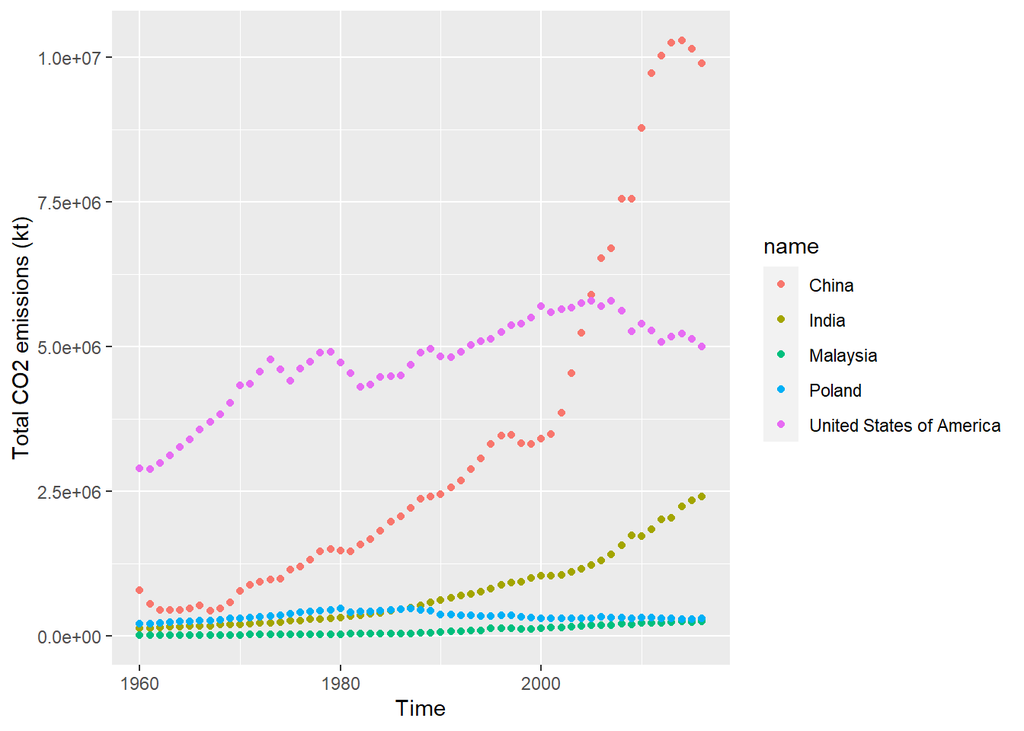

```r
ggplot(co2_countries) +
  geom_point(aes(x = time, y= total_co2_per_year, col = name)) +
  labs(x = "Time", y = "Total CO2 emissions (kt)")
```

```r
co2_PC_countries <- gapminder %>%
  filter(!is.na(co2_PC), name%in%c("United States of America", "China", "India", "Malaysia", "Poland")) %>%
  group_by(time, name) %>%
  reframe(total_co2_per_year = sum(co2_PC), time) %>%
  arrange(name)
```

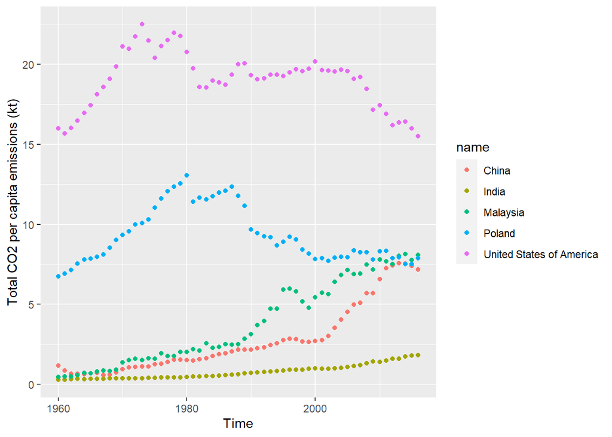

```r
ggplot(co2_PC_countries) +
  geom_point(aes(x = time, y= total_co2_per_year, col = name)) +
  labs(x = "Time", y = "Total CO2 per capita emissions (kt)")
```

- The CO2 emission per capita has been increasing for countries like Malaysia and China over time. India’s CO2 emission per capita has also been increasing, but its rate is not as significant as Malaysia’s and China’s. On the other hand, both the US and Poland’s CO2 emission per capita have increased from 1960 to 1980, but since then, has been decreasing.
4. (6pt) Compute average CO2 emissions per capita across the continents (assume region is the same as continent). Comment what do you see. Note: just compute averages over countries and ignore the fact that countries are of different size. Hint: Americas 2016 should be 4.80.

```r
region_CO2 <- gapminder %>%
  filter(!is.na(region), !is.na(co2_PC)) %>%
  group_by(region, time) %>%
  reframe(av_CO2_PC = mean(co2_PC))
```

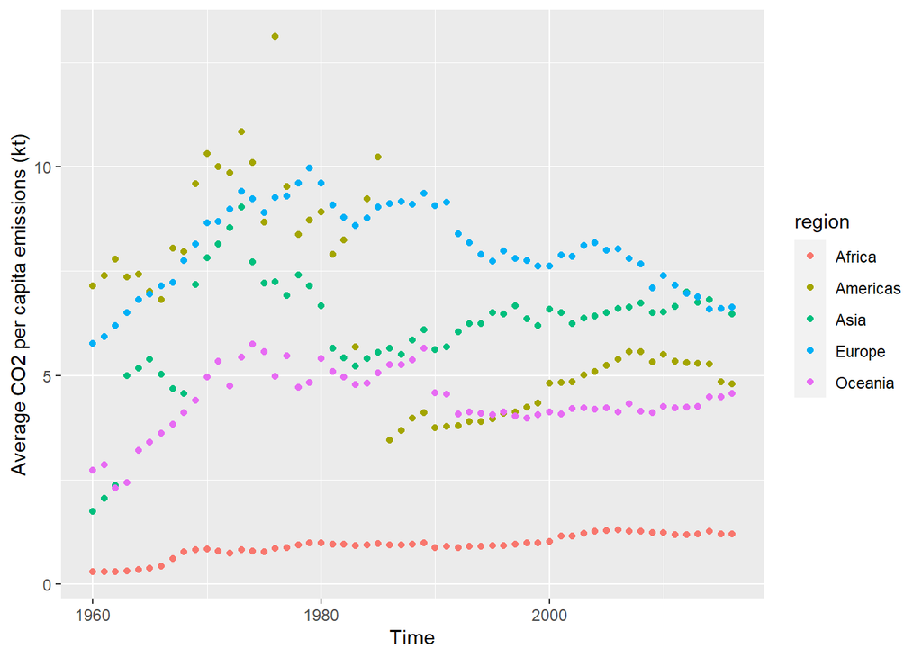

```r
ggplot(region_CO2) +
  geom_point(aes(x = time, y= av_CO2_PC, col = region)) +
  labs(x = "Time", y = "Average CO2 per capita emissions (kt)")
```

- Africa has had a steady increase in average CO2 per capita over time. Every other region had varying average CO2 per capita over time between the 1960s to 1980s. From there, we can observe Europe’s average CO2 per capita over time decreasing, but Asia, Oceania, and the Americas increasing.
5. (7pt) Make a barplot where you show the previous results–average CO2 emissions per capita across continents in 1960 and 2016.

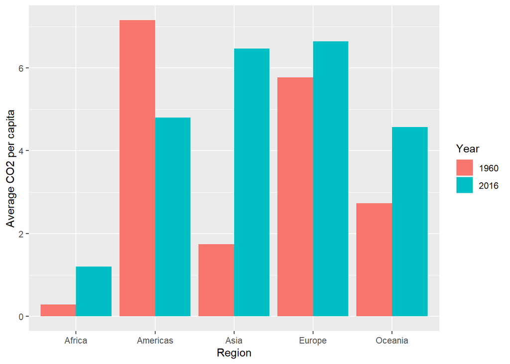

```r
years <- c("1960", "2016")
region_CO2 %>%
  filter(time%in%years) %>%
  ggplot(aes(x=region, y=av_CO2_PC, fill = factor(time))) +
  geom_col(position = "dodge") +
  labs(x = "Region", y = "Average CO2 per capita", fill = "Year")
```

6. Which countries are the three largest, and three smallest CO2 emitters (in terms of CO2 per capita) in 2019 for each continent? (Assume region is continent).
- Since there is no CO2 per capita data in 2019, I used the 2016 data.
- Smallest CO2 emitters in 2016 for each continent:

```r
gapminder %>%
  filter(!is.na(region), !is.na(co2_PC), time == "2016") %>%
  group_by(region, name) %>%
  summarize(smallest_CO2_emitters_2016 = mean(co2_PC), .groups = "drop") %>%
  arrange(region, smallest_CO2_emitters_2016) %>%
  group_by(region) %>%
  slice(1:3)
```

```
## # A tibble: 15 × 3
## # Groups:   region [5]
##    region   name                              smallest_CO2_emitters_2016
##    <chr>    <chr>                                                  <dbl>
##  1 Africa   Congo, Democratic Republic of the                     0.0256
##  2 Africa   Somalia                                               0.0455
##  3 Africa   Burundi                                               0.0472
##  4 Americas Haiti                                                 0.275
##  5 Americas Nicaragua                                             0.887
##  6 Americas Honduras                                              1.06
##  7 Asia     Afghanistan                                           0.245
##  8 Asia     Nepal                                                 0.334
##  9 Asia     Yemen                                                 0.390
## 10 Europe   Liechtenstein                                         1.36
## 11 Europe   Albania                                               1.58
## 12 Europe   Moldova, Republic of                                  1.83
## 13 Oceania  Solomon Islands                                       0.272
## 14 Oceania  Vanuatu                                               0.527
## 15 Oceania  Kiribati                                              0.587
```

- Largest CO2 emitters in 2016 for each continent:

```r
gapminder %>%
  filter(!is.na(region), !is.na(co2_PC), time == "2016") %>%
  group_by(region, name) %>%
  summarize(largest_CO2_emitters_2016 = mean(co2_PC), .groups = "drop") %>%
  arrange(region, desc(largest_CO2_emitters_2016)) %>%
  group_by(region) %>%
  slice(1:3)
```

```
## # A tibble: 15 × 3
## # Groups:   region [5]
##    region   name                     largest_CO2_emitters_2016
##    <chr>    <chr>                                        <dbl>
##  1 Africa   South Africa                                  8.48
##  2 Africa   Libya                                         7.79
##  3 Africa   Seychelles                                    6.39
##  4 Americas Trinidad and Tobago                          31.8
##  5 Americas United States of America                     15.5
##  6 Americas Canada                                       15.1
##  7 Asia     Qatar                                        38.9
##  8 Asia     Kuwait                                       25.0
##  9 Asia     Bahrain                                      22.2
## 10 Europe   Gibraltar                                    18.8
## 11 Europe   Luxembourg                                   15.4
## 12 Europe   Faroe Islands                                13.1
## 13 Oceania  New Caledonia                                19.3
## 14 Oceania  Australia                                    15.5
## 15 Oceania  Palau                                        12.6
```

## GDP per capita (50pt)

1. (8pt) Make a scatterplot of GDP per capita versus life expectancy by country, using data for 1960. Make the point size dependent on the country size, and color those according to the continent. Feel free to adjust the plot in other ways to make it better. Comment what do you see there.

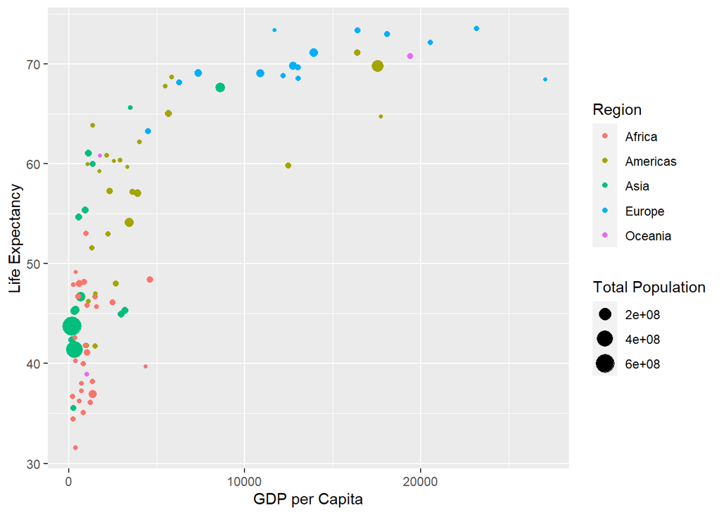

```r
gapminder %>%
  filter(!is.na(GDP_PC), !is.na(lifeExpectancy), !is.na(region), time == "1960") %>%
  group_by(name) %>%
  ggplot(aes(x = GDP_PC, y = lifeExpectancy, col = region)) +
  geom_point(aes(size = totalPopulation)) +
  labs(x = "GDP per Capita", y = "Life Expectancy", size = "Total Population", col = "Region")
```

2. (4pt) Make a similar plot, but this time use 2019 data only.

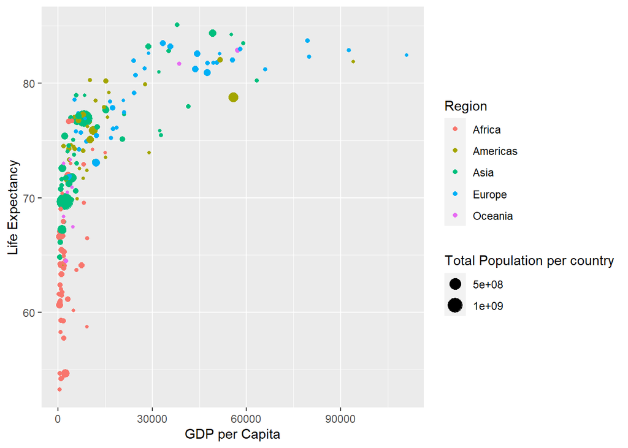

```r
gapminder %>%
  filter(!is.na(GDP_PC), !is.na(lifeExpectancy), !is.na(region), time == "2019") %>%
  group_by(name) %>%
  ggplot(aes(x = GDP_PC, y = lifeExpectancy, col = region)) +
  geom_point(aes(size = totalPopulation)) +
  labs(x = "GDP per Capita", y = "Life Expectancy", size = "Total Population per country", col = "Region")
```

3. (6pt) Compare these two plots and comment what do you see. How has world developed through the last 60 years?
- In the last 60 years, the total population per country has increased as seen by the size of the points. Alongside that, life expectancy has increased, and GDP per capita has significantly increased as well.
4. (6pt) Compute the average life expectancy for each continent in 1960 and 2019. Do the results fit with what do you see on the figures? Note: here as average I mean just average over countries, ignore the fact that countries are of different size.

```r
gapminder %>%
  filter(!is.na(time), time%in%c("1960", "2019"), !is.na(lifeExpectancy)) %>%
  group_by(time) %>%
  summarize(mean(lifeExpectancy))
```

```
## # A tibble: 2 × 2
##    time `mean(lifeExpectancy)`
##   <dbl>                  <dbl>
## 1  1960                   53.9
## 2  2019                   72.9
```

- Yes the results match what I see on the figures
5. (8pt) Compute the average LE growth from 1960-2019 across the continents. Show the results in the order of growth. Explain what do you see. Hint: these data (data in long form) is not the simplest to compute growth. But you may want to check out the lag() function. And do not forget to group data by continent when using lag(), otherwise your results will be messed up

```r
gapminder %>%
  filter(!is.na(region), !is.na(lifeExpectancy), time%in%c(1960, 2019)) %>%
  group_by(region, time) %>%
  summarize(avg_LE = mean(lifeExpectancy)) %>%
  mutate(previous = lag(avg_LE), growth = avg_LE - previous) %>%
  filter(!is.na(growth)) %>%
  arrange(desc(growth))
```

```
## # A tibble: 5 × 5
## # Groups:   region [5]
##   region    time avg_LE previous growth
##   <chr>    <dbl>  <dbl>    <dbl>  <dbl>
## 1 Asia      2019   74.6     51.6   23.0
## 2 Africa    2019   64.1     41.5   22.6
## 3 Americas  2019   75.8     58.6   17.2
## 4 Oceania   2019   73.5     56.4   17.1
## 5 Europe    2019   79.4     68.3   11.1
```

6. (6pt) Show the histogram of GDP per capita for years of 1960 and 2019. Try to put both histograms on the same graph, see how well you can do it!

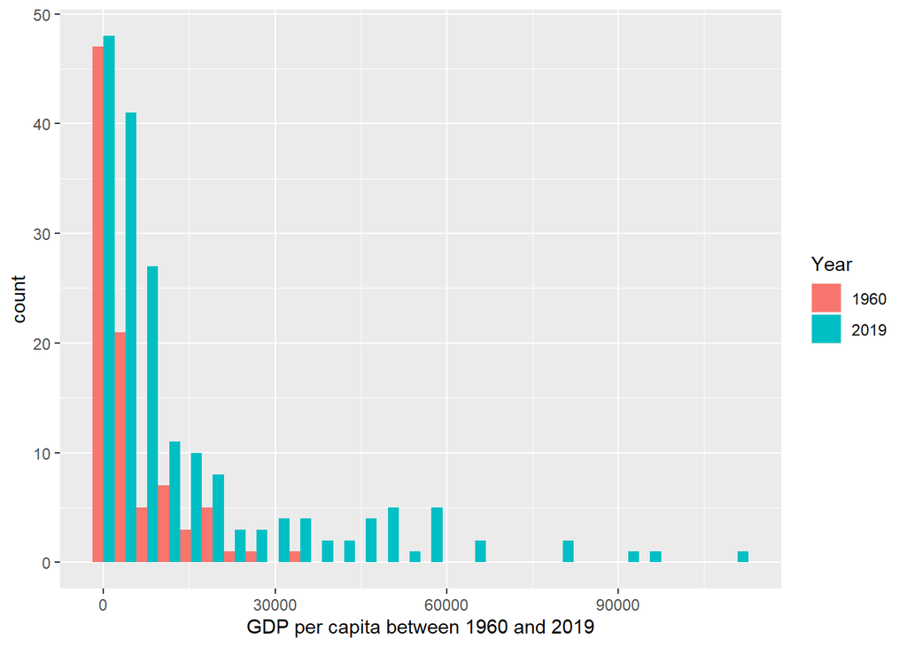

```r
gapminder %>%
  filter(!is.na(GDP_PC), time%in%c("1960", "2019")) %>%
  ggplot(aes(x = GDP_PC, fill = factor(time))) +
  geom_histogram(position = "dodge") +
  labs(x = "GDP per capita between 1960 and 2019", fill = "Year")
```

7. (6pt) What was the ranking of US in terms of life expectancy in 1960 and in 2019? (When counting from top.)

```r
gapminder %>%
  filter(!is.na(name), !is.name(lifeExpectancy), time%in%c(1960, 2019)) %>%
  group_by(time) %>%
  mutate(rank = rank(desc(lifeExpectancy))) %>%
  filter(name == "United States of America") %>%
  summarize(time, rank)
```

```
## # A tibble: 2 × 2
##    time  rank
##   <dbl> <dbl>
## 1  1960    17
## 2  2019    46
```

8. (6pt) If you did this correctly, then you noticed that US ranking has been falling quite a bit. But we also have more countries in 2019–what about the relative rank divided by the corresponding number of countries that have LE data in the corresponding year?

```r
gapminder %>%
    filter(time%in%c(1960, 2019), !is.na(lifeExpectancy), !is.na(region)) %>%
    group_by(time) %>%
    mutate(le_rank = rank(desc(lifeExpectancy)), num_country = n(), relative_rank = le_rank / num_country) %>%
    select(name, le_rank, time, num_country, relative_rank) %>%
    filter(name == "United States of America")
```

```
## # A tibble: 2 × 5
## # Groups:   time [2]
##   name                     le_rank  time num_country relative_rank
##   <chr>                      <dbl> <dbl>       <int>         <dbl>
## 1 United States of America      17  1960         188        0.0904
## 2 United States of America      46  2019         196        0.235
```

# I spent 6 hours on this assignment